# Analysis of results

This notebook explores in different ways, the data selected by the pipeline/vetting process. It should be run only after notebook *results.ipynb* was run, and created file *candidates_best.fits*.

Input is defined by parameter *tel_suffix* in file *settings.py*.

- compares parameters from PSF analysis in between the transient's data and normal stars.
- plots visual summary of transients.
- plots transient locations in their image's FOVs.
- plots timeline.
- computes spatial and temporal coverage statistics.
- displays dependency with distance to center of plate.

```python
import os
import warnings
import json
from collections import Counter
from datetime import datetime

from IPython.display import Markdown, display

import numpy as np

import matplotlib.pyplot as plt
import matplotlib.dates as mdates
import matplotlib.cm as cm
import matplotlib.colors as mcolors
from matplotlib.pyplot import imshow
from matplotlib.colors import LogNorm

from astropy.io import fits
from astropy.wcs import WCS, FITSFixedWarning
from astropy.table import Table
from astropy.coordinates import SkyCoord

import pandas as pd

import settings
from library import plot_psf_analysis, plot_cutout_series, update_dataset, get_par, get_cutouts
from settings import RESULTS, CATALOG, telescope_names, current_dataset, fname, tel_suffix, parameters, sequences
```

```python
display(Markdown("## Analysis of results for telescope: " + telescope_names[tel_suffix]))
```

Analysis of results for telescope: Great Schmidt Camera

```python
SMALL_FWHM = 'small_fwhm'
STELLAR_FWHM = 'stellar_fwhm'
```

```python
pd.set_option('display.max_rows', None)
pd.set_option('display.max_columns', None)

warnings.filterwarnings('ignore', category=FITSFixedWarning)
```

```python
# Image names are not imported, but kept instead in a json file
images_json = 'images.json'
try:
    json_file = open(images_json, 'r')
    images = json.load(json_file)
except FileNotFoundError:
    print(f"Error: File {images_json} was not found.")
except json.JSONDecodeError as e:
    print(f"JSON Error: {e}")
```

## Functions

```python
def plot_frame(plate_id, transients, widths):

    # isolate table row for selected plate
    mask = transients['plate_id_1'] == plate_id
    table_plate = transients[mask]

    # get some info for next image
    plate_id_next = table_plate['plate_id_next'][0]

    seq_key = table_plate['seq'][0]

#     print(table_plate['source_id'])

    # retrieve information from the two plates
    json_file = open('images.json', 'r')
    images = json.load(json_file)

    image_name = images[str(plate_id)]
    header = fits.getheader(fname(image_name))
    date = header['DATE-AVG']
    wcs = WCS(header)
    naxis1 = header['NAXIS1']
    naxis2 = header['NAXIS2']

    image_name_next = images[str(plate_id_next)]
    header = fits.getheader(fname(image_name_next))
    date_next = header['DATE-AVG']

    # identify narrow transients
    small_fwhm_ids = []
    if str(plate_id) in list(widths[SMALL_FWHM].keys()):
        small_fwhm_ids.extend(widths[SMALL_FWHM][str(plate_id)])

    fig = plt.figure(figsize=(4, 4))
    ax = fig.add_subplot(1, 1, 1, projection=wcs)

    # plot frame
    x_corners = [0, naxis1, naxis1, 0, 0]
    y_corners = [0, 0, naxis2, naxis2, 0]
    world_corners = wcs.pixel_to_world(x_corners, y_corners)
    ax.plot(world_corners.ra.deg, world_corners.dec.deg,
        transform=ax.get_transform('world'), color='gray', linewidth=1)

    # plot transient locations
    for row in range(len(table_plate)):
        ra  = table_plate['ra_icrs'][row]
        dec = table_plate['dec_icrs'][row]
        sid = table_plate['source_id'][row]

        # narrow transients are colored in red
        color = 'blue'
        if sid in small_fwhm_ids:
            color = 'red'

        ax.scatter(ra, dec, transform=ax.get_transform('world'), marker='o', s=20,
                   edgecolor=color, facecolor=color)

#         print(table_plate['ra_icrs'][row], table_plate['dec_icrs'][row], table_plate['x_source'][row], table_plate['y_source'][row])

    ax.set_xlabel('R.A')
    ax.set_ylabel('Dec.')
    ax.grid(color='gray', ls='solid', linewidth=1)
    plt.title('Plate1: ' + str(plate_id) + "   file: " + image_name + "  " + seq_key + "   " + date + "\n" +
              'Plate2: ' + str(plate_id_next) + "   file: " + image_name_next + "               " + date_next)
    plt.tight_layout()

    plt.show()
```

```python
def update_widths(plate, widths, transients, reference):
    '''
    Build dict that stores subsets of source ID values corresponding to "narrow" and
    "stellar" image profiles. In each subset, source IDs are stored in lists, one list
    per plate ID.

    Parameters:

    plate         - plate ID
    widths        - dict to be updated
    transients    - table with transients for the given plate
    reference     - table with Gaussian-fitted stars for the given plate

    Returns:

    widths        - the input dictionary, updated with the transient source ID
                    for this plate
    '''
    # update result dict with empty entries for this plate
    widths[SMALL_FWHM][str(plate)] = []
    widths[STELLAR_FWHM][str(plate)] = []

    half_range = 500.

    for row in range(len(transients)):
        source_id = transients['source_id'][row]

        # find stars in an interval of peak flux that have similar
        # peak fluxes as the transient
        flux_transient = transients['flux_max'][row]
        flux_low  = flux_transient - half_range
        flux_high = flux_transient + half_range

        indices = np.where((reference['flux_max'] >= flux_low) & (reference['flux_max'] <= flux_high))

        # get minimum FWHM among these stars
        min_fwhm = min(reference['fwhm_fit'][indices])

        # see if transient is narrow or stellar
        transient_fwhm = transients['fwhm_fit'][row]
        if transient_fwhm < min_fwhm:
            key = SMALL_FWHM
        else:
            key = STELLAR_FWHM

        # update appropriate dict with this source ID
        widths[key][str(plate)].append(source_id)

    return widths
```

## Main input table with transient info

```python
table_transients = Table.read(os.path.join(RESULTS, "candidates_best_" + tel_suffix + ".fits"), format='fits')

table_transients.sort(['ut_mid'])
```

```python
df = table_transients.to_pandas()
table_transients
display(df)
```

|  | seq | ut_mid | exptime | es | plate_id_next | ut_mid_next | exptime_next | es_next | source_id | process_id_1 | scan_id_1 | plate_id_1 | archive_id_1 | solution_num | annular_bin_1 | dist_center_1 | dist_edge_1 | sextractor_flags_1 | model_prediction_1 | ra_icrs | dec_icrs | ra_error | dec_error | gal_lon | gal_lat | ecl_lon | ecl_lat | x_sphere | y_sphere | … |
| --- | --- | --- | --- | --- | --- | --- | --- | --- | --- | --- | --- | --- | --- | --- | --- | --- | --- | --- | --- | --- | --- | --- | --- | --- | --- | --- | --- | --- | --- | --- |
| 0 | b'seq01' | b'1953-09-05 00:10:00' | 1200 | 74.194733 | 66587 | b'1953-09-05 00:10:00' | 1200 | 74.184914 | 40528680022050 | 52868 | 74248 | 66586 | 3 | 0 | 4 | 4171.1836 | 2148.8535 | 0 | 0.999969 | 56.265709 | 25.519490 | 0.110499 | 0.105235 | 165.195684 | -22.771031 | 59.770984 | 5.551900 | 0.501162 | 0.750488 | … |
| 1 | b'seq01' | b'1953-09-05 00:10:00' | 1200 | 74.184914 | 66588 | b'1953-09-05 00:10:00' | 1200 | 74.195541 | 40528690019802 | 52869 | 74249 | 66587 | 3 | 0 | 5 | 4638.8975 | 1608.3606 | 0 | 0.978047 | 58.572581 | 23.726235 | 0.110280 | 0.101844 | 168.185055 | -22.670937 | 61.438956 | 3.349881 | 0.477347 | 0.781179 | … |
| 2 | b'seq01' | b'1953-09-05 00:10:00' | 1200 | 74.184914 | 66588 | b'1953-09-05 00:10:00' | 1200 | 74.195541 | 40528690011059 | 52869 | 74249 | 66587 | 3 | 0 | 4 | 3788.1190 | 2404.9143 | 0 | 0.999992 | 56.552301 | 22.816549 | 0.110280 | 0.101844 | 167.384497 | -24.603295 | 59.428481 | 2.857731 | 0.508047 | 0.769099 | … |
| 3 | b'seq01' | b'1953-09-05 00:10:00' | 1200 | 74.184914 | 66588 | b'1953-09-05 00:10:00' | 1200 | 74.195541 | 40528690016740 | 52869 | 74249 | 66587 | 3 | 0 | 7 | 5690.8050 | 821.4404 | 0 | 1.000000 | 54.850626 | 23.285089 | 0.110280 | 0.101844 | 165.753573 | -25.299532 | 58.005437 | 3.665898 | 0.528818 | 0.751055 | … |
| 4 | b'seq01' | b'1953-09-05 00:10:00' | 1200 | 74.184914 | 66588 | b'1953-09-05 00:10:00' | 1200 | 74.195541 | 40528690031986 | 52869 | 74249 | 66587 | 3 | 0 | 4 | 4012.1590 | 2704.5781 | 0 | 1.000000 | 55.501996 | 24.846893 | 0.110280 | 0.101844 | 165.115013 | -23.732558 | 58.943134 | 5.051231 | 0.513950 | 0.747858 | … |
| 5 | b'seq01' | b'1953-09-05 00:10:00' | 1200 | 74.184914 | 66588 | b'1953-09-05 00:10:00' | 1200 | 74.195541 | 40528690026830 | 52869 | 74249 | 66587 | 3 | 0 | 2 | 2371.9893 | 3767.7910 | 0 | 1.000000 | 57.724235 | 24.338473 | 0.110280 | 0.101844 | 167.118561 | -22.756534 | 60.808906 | 4.111458 | 0.486537 | 0.770347 | … |
| 6 | b'seq01' | b'1953-09-05 00:10:00' | 1200 | 74.184914 | 66588 | b'1953-09-05 00:10:00' | 1200 | 74.195541 | 40528690028681 | 52869 | 74249 | 66587 | 3 | 0 | 3 | 3061.9167 | 3205.5360 | 0 | 0.999868 | 57.936511 | 24.527021 | 0.110280 | 0.101844 | 167.132611 | -22.486842 | 61.038429 | 4.254672 | 0.482957 | 0.770990 | … |
| 7 | b'seq01' | b'1953-09-05 00:10:00' | 1200 | 74.184914 | 66588 | b'1953-09-05 00:10:00' | 1200 | 74.195541 | 40528690020195 | 52869 | 74249 | 66587 | 3 | 0 | 4 | 3904.8252 | 2340.2705 | 0 | 1.000000 | 55.415541 | 23.677738 | 0.110280 | 0.101844 | 165.896683 | -24.662504 | 58.600768 | 3.930148 | 0.519837 | 0.753985 | … |
| 8 | b'seq01' | b'1953-09-05 00:10:00' | 1200 | 74.184914 | 66588 | b'1953-09-05 00:10:00' | 1200 | 74.195541 | 40528690030185 | 52869 | 74249 | 66587 | 3 | 0 | 3 | 3622.8242 | 2793.9482 | 0 | 0.999989 | 55.547126 | 24.622365 | 0.110280 | 0.101844 | 165.310479 | -23.874368 | 58.932277 | 4.823233 | 0.514289 | 0.749615 | … |
| 9 | b'seq01' | b'1953-09-05 00:10:00' | 1200 | 74.184914 | 66588 | b'1953-09-05 00:10:00' | 1200 | 74.195541 | 40528690038198 | 52869 | 74249 | 66587 | 3 | 0 | 6 | 5123.3306 | 1778.7324 | 0 | 0.999800 | 55.703775 | 25.608302 | 0.110280 | 0.101844 | 164.718800 | -23.039153 | 59.294409 | 5.751832 | 0.508122 | 0.744984 | … |
| 10 | b'seq01' | b'1953-09-05 00:10:00' | 1200 | 74.184914 | 66588 | b'1953-09-05 00:10:00' | 1200 | 74.195541 | 40528690010193 | 52869 | 74249 | 66587 | 3 | 0 | 8 | 6024.4960 | 1524.1826 | 0 | 0.999943 | 55.149780 | 22.675810 | 0.110280 | 0.101844 | 166.428491 | -25.574478 | 58.134538 | 3.009756 | 0.527262 | 0.757213 | … |
| 11 | b'seq01' | b'1953-09-05 00:10:00' | 1200 | 74.194733 | 66587 | b'1953-09-05 00:10:00' | 1200 | 74.184914 | 40528680007223 | 52868 | 74248 | 66586 | 3 | 0 | 5 | 4545.3086 | 2608.7861 | 0 | 1.000000 | 55.770357 | 22.884987 | 0.110499 | 0.105235 | 166.746221 | -25.037239 | 58.740063 | 3.084307 | 0.518234 | 0.761711 | … |
| 12 | b'seq01' | b'1953-09-05 00:10:00' | 1200 | 74.194733 | 66587 | b'1953-09-05 00:10:00' | 1200 | 74.184914 | 40528680015391 | 52868 | 74248 | 66586 | 3 | 0 | 3 | 3554.7444 | 2612.2520 | 0 | 1.000000 | 58.187515 | 24.406232 | 0.110499 | 0.105235 | 167.402405 | -22.418911 | 61.236804 | 4.088389 | 0.480035 | 0.773841 | … |
| 13 | b'seq01' | b'1953-09-05 00:10:00' | 1200 | 74.194733 | 66587 | b'1953-09-05 00:10:00' | 1200 | 74.184914 | 40528680023802 | 52868 | 74248 | 66586 | 3 | 0 | 8 | 6885.0757 | 1152.1564 | 0 | 1.000000 | 58.724305 | 25.869987 | 0.110499 | 0.105235 | 166.705343 | -21.019134 | 62.020457 | 5.418477 | 0.467130 | 0.769029 | … |
| 14 | b'seq01' | b'1953-09-05 00:10:00' | 1200 | 74.194733 | 66587 | b'1953-09-05 00:10:00' | 1200 | 74.184914 | 40528680014221 | 52868 | 74248 | 66586 | 3 | 0 | 1 | 1681.4940 | 4427.9985 | 0 | 1.000000 | 57.490980 | 24.194663 | 0.110499 | 0.105235 | 167.055494 | -23.006580 | 60.569830 | 4.016391 | 0.490223 | 0.769229 | … |
| 15 | b'seq01' | b'1953-09-05 00:10:00' | 1200 | 74.194733 | 66587 | b'1953-09-05 00:10:00' | 1200 | 74.184914 | 40528680019111 | 52868 | 74248 | 66586 | 3 | 0 | 2 | 2624.5393 | 3500.8271 | 0 | 1.000000 | 56.974664 | 25.063310 | 0.110499 | 0.105235 | 166.043304 | -22.682967 | 60.298303 | 4.965957 | 0.493692 | 0.759483 | … |
| 16 | b'seq01' | b'1953-09-05 00:10:00' | 1200 | 74.194733 | 66587 | b'1953-09-05 00:10:00' | 1200 | 74.184914 | 40528680011021 | 52868 | 74248 | 66586 | 3 | 0 | 6 | 5312.2246 | 998.9541 | 0 | 0.999745 | 54.901398 | 23.566697 | 0.110499 | 0.105235 | 165.587495 | -25.056872 | 58.115624 | 3.929331 | 0.527029 | 0.749925 | … |
| 17 | b'seq01' | b'1953-09-05 00:10:00' | 1200 | 74.194733 | 66587 | b'1953-09-05 00:10:00' | 1200 | 74.184914 | 40528680017767 | 52868 | 74248 | 66586 | 3 | 0 | 1 | 2078.1516 | 4214.2180 | 0 | 0.999685 | 57.166537 | 24.816732 | 0.110499 | 0.105235 | 166.362689 | -22.748345 | 60.415050 | 4.687482 | 0.492130 | 0.762657 | … |
| 18 | b'seq01' | b'1953-09-05 00:10:00' | 1200 | 74.184914 | 66588 | b'1953-09-05 00:10:00' | 1200 | 74.195541 | 40528690019478 | 52869 | 74249 | 66587 | 3 | 0 | 3 | 3415.1530 | 2945.6220 | 0 | 1.000000 | 55.651891 | 23.605627 | 0.110280 | 0.101844 | 166.127489 | -24.572778 | 58.795886 | 3.811036 | 0.517008 | 0.756539 | … |
| 19 | b'seq01' | b'1953-09-05 00:10:00' | 1200 | 74.184914 | 66588 | b'1953-09-05 00:10:00' | 1200 | 74.195541 | 40528690012231 | 52869 | 74249 | 66587 | 3 | 0 | 7 | 5740.4434 | 1418.7090 | 0 | 1.000000 | 55.099512 | 22.882142 | 0.110280 | 0.101844 | 166.238422 | -25.450798 | 58.136412 | 3.221236 | 0.527128 | 0.755607 | … |

## Plate pairs with transients

In here, we build the list of plate IDs with transients.

```python
plate_id_list = table_transients['plate_id_1']
counts = Counter(plate_id_list)
counter = [(item, count) for item, count in counts.items()]

print(counter)
```

```
[(66586, 8), (66587, 12)]
```

## PSF analysis

We want to compare each transient's FWHM (and other parameters) with the same parameters from a sample of stars *from the same plate as the transient*. Looking for any systematic effect that could inform about the nature of the transients.

Code below displays these parameters (as a function of peak flux):

- ***FWHM***: width of Gaussian fit to the object.
- ***elongation***: sextractor-produced ratio between major and minor axis of ellipse fit to the object.
- ***qfit***: a quality-of-fit metric produced by the Gaussian fitting library, defined as the sum of the absolute value of the fit residuals divided by the fit flux. qfit is zero for sources that are perfectly fit by the PSF model.
- ***cfit***: a quality-of-fit metric produced by the Gaussian fitting library, defined as the fit residual (data - model) in the initial central pixel value divided by the fit flux. Large positive values indicate sources that are sharper than the PSF model (e.g., cosmic ray, hot pixel, etc.). Large negative values indicate sources that are broader than the PSF model

Code below also segregates transients into "narrow" and "stellar" categories, based on how their FWHM compares with the FWHM of similar stars of same brightness.

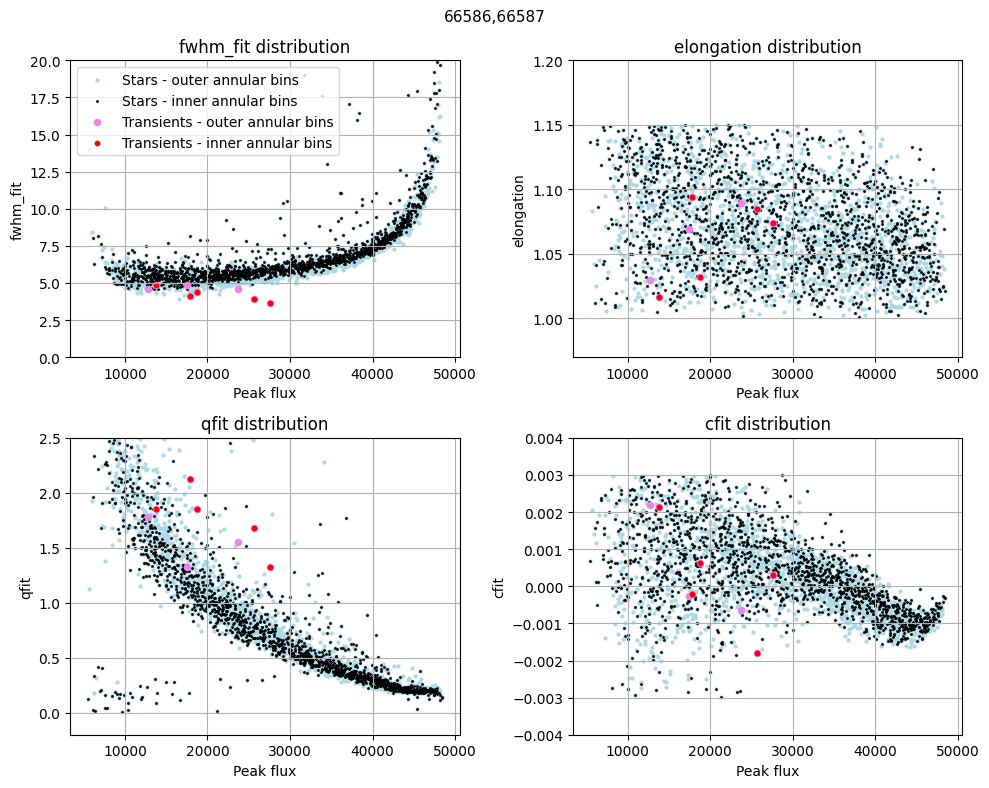

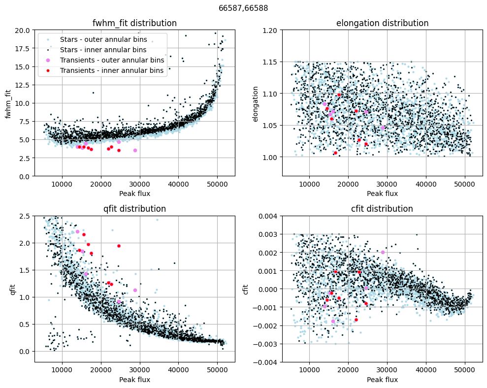

```python
# this dict stores subsets of source ID values corresponding to "narrow" and
# "stellar" image profiles. In each subset, source IDs are stored in lists,
# one list per plate ID.
widths = {
    SMALL_FWHM: {},
    STELLAR_FWHM: {},
}

for plate_id, *_ in counter:

    # isolate rows for selected plate
    mask = table_transients['plate_id_1'] == plate_id
    table_transients_plate = table_transients[mask]

    par, dataset_key = get_par(table_transients_plate)

    # finally, get table with star data
    table_reference  = Table.read(fname(par['table_psf_matched']), format='fits')

    # now, it's time to plot
    _ = plot_psf_analysis([table_reference, table_transients_plate], par, title=dataset_key,
                      labels=[['Stars - outer annular bins', 'Stars - inner annular bins'],
                              ['Transients - outer annular bins', 'Transients - inner annular bins']],
                       sizes = [[4, 1], [20, 10]])

#     for row in range(len(table_transients_plate)):
#         print(table_transients_plate['flux_max'][row], table_transients_plate['fwhm_fit'][row],
#               table_transients_plate['source_id'][row])

    # update widths dict with data from this plate
    widths = update_widths(plate_id, widths, table_transients_plate, table_reference)

    print()
    print()
```

### Discussion:

One can see a significant number of transients that have a smaller FWHM than stars of same brightness. Their shapes (qfit) tend to depart from a Gaussian more than a typical star image does.

The narrower, the more they depart from the qfit=0 locus. There are quite a few counterexamples in several plates, where transients have FWHM values indistinguishable from stars, and also shapes closer to Gaussian.

So, maybe we are facing two classes of objects? One of them might be just plate artifacts not yet accounted for? It would be informative to segregate objects in these two classes based on the diagrams above, and then look at their images on the sky.

**Note**: the systematic difference seen in stars at inner and outer annular bins (Applause concept to measure distance to center of plate) is caused by slight defocussing (likely the glass plate was not bent to the exact shape of the focal surface). The effect can be seen very clearly in a few plates, in which the analysis included only the more central annular bins ("inner" and "outer" mean the inner and outer half of the range of annular bins actually included in the analysis).

The data is too scant to enable any additional conclusion though.

### Two populations

Lets separate the two cases mentioned above:

- transient FWHM smaller than star's
- transient FWHM similar to star's

The separation code is implemented in function *update_widths* defined above.

Now we look at the transients themselves, with plots grouped together by class of FWHM.

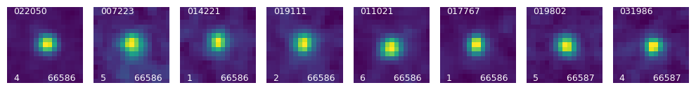

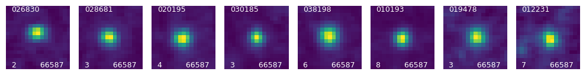

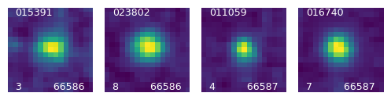

```python
plates = widths[SMALL_FWHM]
plot_cutout_series(plates, table_transients, images, None)
print('----------------------------------------------------------------------')
plates = widths[STELLAR_FWHM]
plot_cutout_series(plates, table_transients, images, None)
```

The first set above contains the narrow transients; the second set, the transients with widths indistinguishable from stars in the same plate, with same brightness. The *qfit* plots at the top of the PSF section also tell us that transients in the second set have shapes closer to a Gaussian shape, than transients in the first set (although both transients *and* stars have somewhat non-Gaussian shapes, with the difference from a Gaussian being dependent on brightness - an expected outcome given the non-linearity of photographic plates).

The numbers in each thumbnail plot are:

- **top**: source ID
- **bottom left**: the *annular_bin* where the transient is found on the plate. That's an APPLAUSE concept that encodes the distance from the plate center, 1 being closest to the center, up to 9 at the edge. Because at the edge the camera focus can be a little off, and because there is evidence (cite?) that plate edges tend to hold more artifacts, we can use it to help in telling apart "true" transients from artifacts.
- **bottom right**: plate Id

It's hard to see any significant difference in between the two groups, aside from the (expected) fact that the second group has in general fuzzier images with more of an extended halo. A few cases seem to suggest a slight asymetry in the central region, but examining them against similar plots of stars in the neighborhood, it is difficult to reject them based solely on that impression.

For comparison with actual star images, the pipeline output files in subdirectory *results/* show similar thumbnail images for each comparison star used with each transient.

For now, we can not rule out the hypothesis that these transients, especially the narrow ones, are real, caused by brief pulses of light that passed thru the optics (and thus weren't so much affected by seeing). Afaik, we lack an hypothesis to explain how plate artifacts, or scanner effects, would cause star-like images with the properties we see here.

## Distribution over the FOV

For each plate in dict above, we create a plot of the transients within the FOV.

**Red** transients have narrower FWHMs than stars. **Blue** transients are indisguinshable from stars of the same magnitude on the same plate.

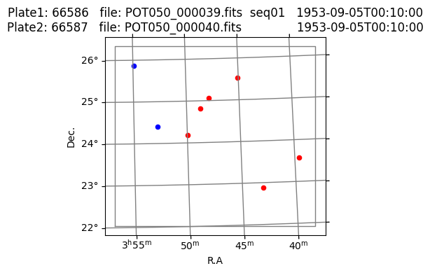

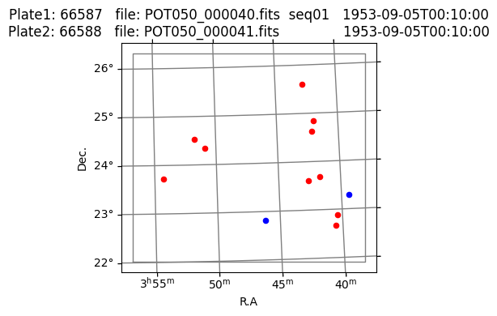

```python
for plate_id, *_ in counter:
    plot_frame(plate_id, table_transients, widths)
```

Plates with a lot of transients could lead us to suspect that they could be in fact plate artifacts that still elude characterization as such. A visual and detailed exam of each one is warranted.

Maybe artifacts caused by a bad batch of chemical developer/fixer, or a plate faulty envelope that led to contamination by dust, or something in those lines. We should check dates against the VASCO event dates, and the "atomic bomb hypothesis" and "UAP sightings hypothesis" just in case. And maybe search for more information about these plates' origins and history.

## Timeline

Plot a timeline graph depicting number of events on each plate.

Sequences of plates (including isolated 2-plate pairs) with no events detected are displayed as white markers with no stem attached.

```python
# some metadata has to be retrieved from the primary input table produced by APPLAUSE
table_input = Table.read(CATALOG, format='ascii.csv')
```

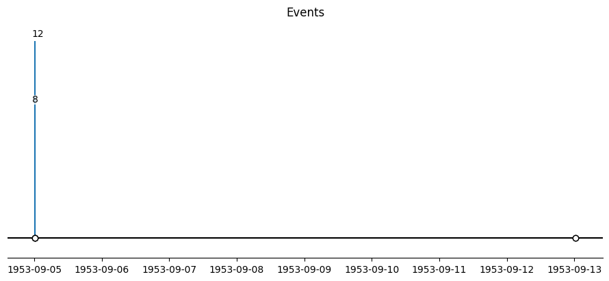

```python
# levels are defined by number of events in sequence, so they can be depicted by stems
levels = []
dates = []

plate_ids, counter_values = zip(*counter)

for sequence in sequences.values():
    for plate_id in sequence:

        m = table_input['plate_id'] == plate_id
        t = table_input[m]
        date = t['ut_mid'][0]

        if plate_id in plate_ids:
            i = plate_ids.index(plate_id)
            level = counter_values[i]
        else:
            level = 0

        levels.append(level)
        dates.append(date)

dates = [datetime.strptime(d, "%Y-%m-%d %H:%M:%S") for d in dates]

# plot
fig, ax = plt.subplots(figsize=(8.8, 4), layout="constrained")
ax.set(title="Events")

# stems, baseline, and markers
ax.vlines(dates, 0, levels)
ax.axhline(0, c="black")
ax.plot(dates, np.zeros_like(dates), "ko", mfc="white")

# annotations
for date, level in zip(dates, levels):
    if level > 0:
        ax.annotate(str(level), xy=(date, level),
                    xytext=(-3, np.sign(level)*5), textcoords="offset points",
                    bbox=dict(boxstyle='square', pad=0, lw=0, fc=(1, 1, 1, 0.7)))

# Remove the y-axis and some spines.
ax.yaxis.set_visible(False)
ax.spines[["left", "top", "right"]].set_visible(False)

ax.margins(y=0.1)
plt.show()
```

## Spatial and temporal coverage stats

We use metadata to compute the total spatial and temporal coverage of the entire dataset. The purpose is to get detection rates per angular unit and per plate area unit. When comparing data from different telescopes, that might yeld clues about the origin of the transients: either ligth coming from the sky, or artifacts coming from the plates themselves.

```python
# total number of events
total_events = sum([count for item, count in counter])
```

```python
total_plate_pairs = 0
total_plate_area  = 0.    # plate areas in cm2
total_fov_area    = 0.    # FOV areas in deg2
total_exptime     = 0

# average (or most common) correction for the areas actually used
area_factor = parameters['default']['annular_bin'] / 10.

for plate_id_list in sequences.values():
    total_plate_pairs += len(plate_id_list) - 1

# all plates listed in the 'sequences' dict
nested_plate_ids = sequences.values()
plate_ids = sum(nested_plate_ids, [])

# plate areas and exposure times add on a per plate basis
for plate_id in plate_ids:
    m = table_input['plate_id'] == plate_id
    table_plate = table_input[m][0]

    # get plate area
    tokens = table_plate['plate_format'].split('x')
    plate_area = float(int(tokens[0]) * int(tokens[1]))
    # plate areas need to be corrected by the annular bin factor.
    # Use the average for now, but we should use the real factor
    # for each plate. Right now, the error introduced by this
    # simplification is negligible.
    plate_area *= area_factor
    total_plate_area += plate_area

    # exptime
    total_exptime += table_plate['exptime']

    # get FOV
    fov1 = table_plate['fov1']
    fov2 = table_plate['fov2']
    total_fov_area += fov1 * fov2 * area_factor   # annular bin correction

    # Should FOVs add on a per sequence basis, since the same FOV is shared by
    # all plates in the same sequence? NO.
    # Since we are not looking for objects attached to the sky, but to just
    # any light that makes its way thru telescope optics, regardless of its
    # origins.

total_exptime /= 3600.
total_plates = len(plate_ids)
rate_area = total_events / total_plate_area / total_exptime
rate_deg  = total_events / total_fov_area / total_exptime
rate_plate = total_events / total_plate_pairs

print("Total plates:               ", total_plates)
print("Total plate pairs:          ", total_plate_pairs)
print("Total plates w/ transients: ", len(counter))
print("Total transients:           ", total_events)
print("Total exptime:              ", f"{total_exptime:.2f}", " (hour)")
print("Total sky area:             ", f"{total_fov_area:.2f}", " (deg^2)")
print("Total plate area:           ", f"{total_plate_area:.1f}", " (cm^2)")
print("Rate per plate pair:        ", f"{rate_plate:.2f}", " (transients/plate pair)")
print("Rate per sky area:          ", f"{rate_deg:.7f}", " (transients/sq deg/hour)")
print("Rate per plate area:        ", f"{rate_area:.7f}", " (transients/cm^2/hour)")
```

```
Total plates:                5
Total plate pairs:           3
Total plates w/ transients:  2
Total transients:            20
Total exptime:               3.00  (hour)
Total sky area:              73.56  (deg^2)
Total plate area:            676.0  (cm^2)
Rate per plate pair:         6.67  (transients/plate pair)
Rate per sky area:           0.0906231  (transients/sq deg/hour)
Rate per plate area:         0.0098619  (transients/cm^2/hour)
```

## Distance to center

The distribution of FWHM as a function of distance may show a slight trend of increasing FWHM as one moves from center to edge of plate, or no trend at all, depending on the data set being analyzed.

Such trend is apparent in some plates whith bad focus, but these were either removed from the analysis altogheter, or the analysis was performed only on the central region, when the focus issue affected only the regions near the plate edges.

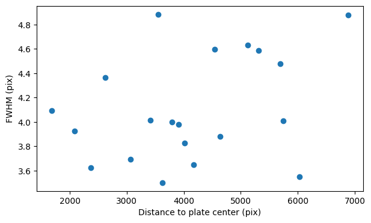

```python
x = table_transients['dist_center_1']
y = table_transients['fwhm_fit']

fig_1 = plt.figure(figsize=(7, 4))
ax = fig_1.add_subplot(1,1,1)
ax.scatter(x, y)
ax.set_xlabel("Distance to plate center (pix)")
ax.set_ylabel("FWHM (pix)")
fig_1.show()
```